# Paradata

Survey Research Methodology II, MUCSS

Dr. Marga Torre

margarita.torre@uc3m.es

## Outline

1. What are paradata?
2. Types of paradata
3. Uses of paradata
4. Examples
5. Useful references

## What are paradata?

**Paradata** are data generated during the survey data collection process. They capture *how* data are collected rather than *what* respondents answer.

They can be:

- **Automatically generated** (timestamps, question order, response times)
- **Recorded by interviewers** (observations, contextual notes)
- **Captured through devices** (keystrokes, voice features)

## Why are paradata important?

The study of paradata is rapidly [expanding](https://www.jstor.org/stable/23355174)

Paradata help answer questions such as:

- How long do respondents spend on each question?
- Do response times vary by question type?
- Are respondents satisficing or answering randomly?
- Do response patterns differ across survey modes (face-to-face vs. online)?

## What are paradata used for?

In general, paradata are used to improve both **data quality** and **fieldwork efficiency**:

- **Data collection process**: Improves efficiency by, for example, identifying optimal contact times and streamlining operations.
- **Data quality**: Highlights issues related to question wording, order, and other design aspects, helping to enhance the accuracy of responses.
- **Social research**: Provides insights into respondent behaviors (e.g., systematic nonresponse), helping to refine survey strategies and methodologies.

## The rise of Web Paradata

Over the past two decades, surveys have shifted toward computer-assisted methods.

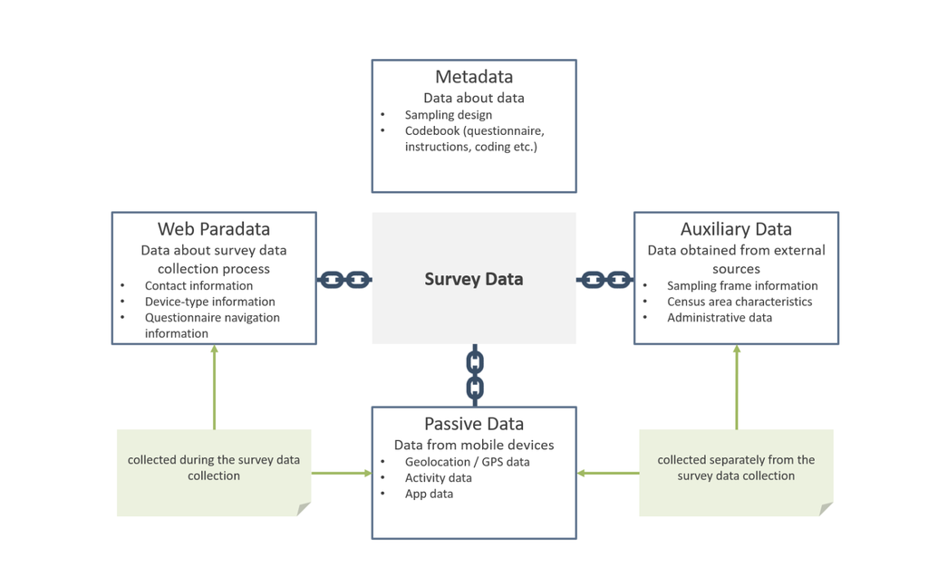

Web paradata vs. other data types (Kunz & Hadler, 2020)

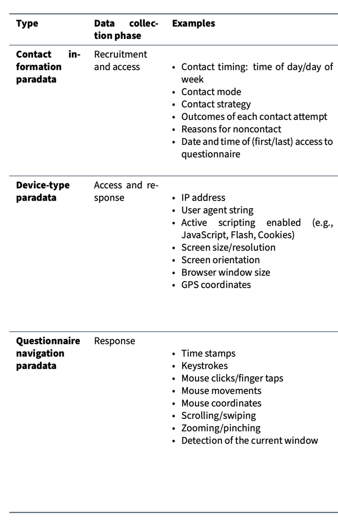

Paradata types and examples (Kunz & Hadler, 2020)

## Web Paradata: Call record data

Call record data help improve survey fieldwork by making contact strategies smarter and more efficient.

1. **Timing patterns**: Show when contact attempts are made and which times work best.
2. **Contact outcomes**: Record whether the respondent was reached, unavailable, or refused.
3. **Planning support**: Help decide when and how often to try again, improving overall call strategy.

## Web Paradata: Response time

Response time (time taken to answer a question) is one of the most commonly used forms of paradata and can be linked to response accuracy and data quality.

### Factors that **increase** response time

- Ambiguous wording
- Inefficient survey design
- Lengthy questions
- Complex questions

### Factors that **decrease** response time

- Logical sequencing of questions
- Respondent familiarity with surveys (*survey professionalism*)
- Reduced respondent motivation

Response times can also help detect potential **interviewer falsification**.

## Web Paradata: Keystroke data

**Keystroke dynamics** — also known as *keystroke biometrics* or *typing dynamics* — analyze the timing of key presses and releases while a person types.

### What can it reveal?

- User authentication (legitimate user vs. impostor)
- Age prediction
- Detection of multiple users on the same device

See this Kaggle challenge on identifying users based on typing patterns:  
[Keystroke Dynamics Analysis and Prediction (XGBoost)](https://www.kaggle.com/code/kartik2112/keystroke-dynamics-analysis-and-prediction-w-xgb)

## Other types of paradata: interviewer observations and characteristics

Includes both what the interviewer observes during the interview (e.g., respondent behavior or context) and the interviewer’s own characteristics (e.g., demographics, experience)

**What is recorded?**

- Housing / environmental conditions
- Respondent behavior
- Third persons / interruptions
- Interviewer characteristics (e.g., gender, age, experience)
- Interviewer evaluations of cooperation or difficulty

**What does it help assess?**

- Interview quality
- Context effects
- Potential bias
- Interviewer effects on responses
- Data reliability and consistency

ESS, for example, offers [data from interviewers](https://ess.sikt.no/en/datafile/c2983fdf-3b0f-4512-94e5-959d9c10f083/42?tab=0) for all its rounds.

Please note that the Eurobarometer you are using for the challenge also includes a section called “INTERVIEW PROTOCOL”, which contains questions such as whether other people (e.g., family members) were present during the interview, and/or duration of the interview.

## Voice Characteristics (CATI)

Audio features of respondents’ speech collected during CATI interviews, used as paradata to enrich and better understand survey responses.

**What is captured?**

- Speech rate & pitch
- Pauses / hesitations
- Disfluencies (“um”, “ah”)
- Intonation patterns
- Response latency (time to answer)

**What does it help detect?**

- Cognitive difficulty
- Uncertainty / emotions
- Possible falsification
- Interviewer–respondent interaction dynamics
- Response sensitivity

## Example of paradata use

[Here is a real example using Wave 1 of the 2014 Survey of Income and Program Participation (SIPP)](https://www.census.gov/newsroom/blogs/research-matters/2017/04/paradata.html)

The average sick days reported vary between self-reports and proxy reports from another household member:

- Individuals aged 15-59 report an average of 6.1 sick days, compared to 3.7 days in proxy reports.
- For those aged 60+, proxy reports show 14.2 sick days versus 7.4 days in self-reports.

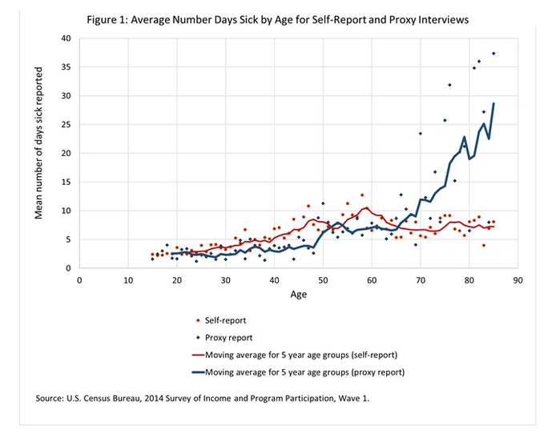

Figure 1

## Example of paradata use

Figure 2 shows the estimated difference in reported sick days based on whether the information was self-reported or reported by a proxy, using a regression model:

- For ages 15-59, proxy reports show 1.2 fewer sick days
- For ages 60+, proxy reports show 4.7 more sick days than self-reports.

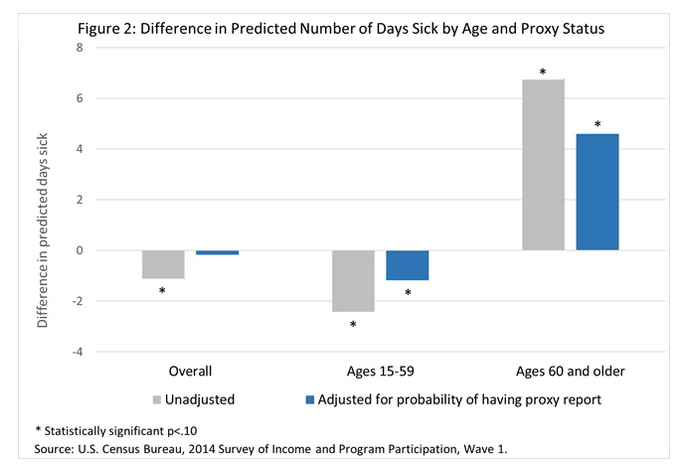

Figure 2

**Why do you think this is happening?**

## Other examples

- [Paradata from Political Web Surveys](https://www.openicpsr.org/openicpsr/project/100041/version/V3/view)
- [Paradata to Shed Light on Data Quality Issues in Online Surveys](https://aapor.org/newsletters/paradata-shed-light/)
- [Using Paradata to Evaluate Youth Participation in a Digital Diary Study](https://www.ncbi.nlm.nih.gov/pmc/articles/PMC8775099/)
- [Using Paradata in Electronic Business Survey Questionnaires](https://onlinelibrary.wiley.com/doi/abs/10.1002/9781119672333.ch18)

## References

- Callegaro, M. (2013). [Paradata in Web Surveys](https://onlinelibrary.wiley.com/doi/abs/10.1002/9781118596869.ch11). In F. Kreuter (Ed.), Improving Surveys with Paradata. Analytic Uses of Process Information (pp. 261–279). Hoboken, NJ: Wiley & Sons
- Couper, M. P. (1998). Measuring Survey Quality in a Casic Environment. Proceedings of American Statistical Association: Survey Research Methods Section, 41-49. Retrieved from http://www.asasrms.org/Proceedings/papers/1998_006.pdf
- Huvila, I., Andersson, L., & Sköld, O. (Eds.). (2024). [Perspectives on paradata](https://link.springer.com/book/10.1007/978-3-031-53946-6). Springer.
- Vannette, D.L. and Krosnick, J.A. eds., 2017. The Palgrave handbook of survey research. Springer

Master in Computational Social Sciences (UC3M)